# Setup

#### Self-Efficacy

I first compare likes and likes plus dislikes to the control condition.

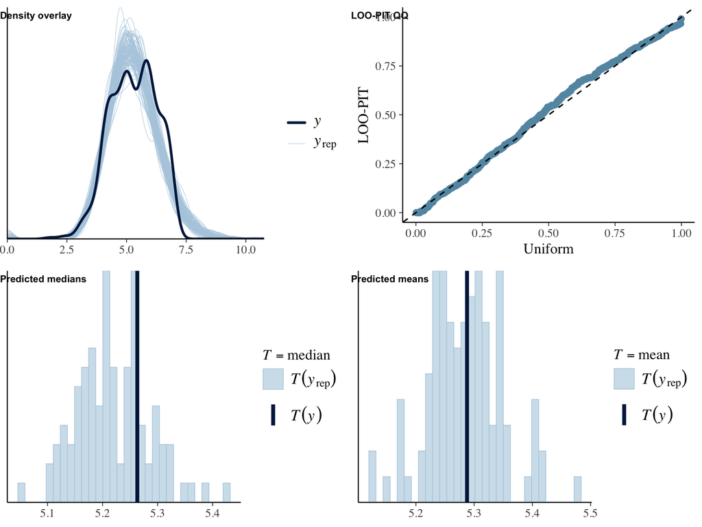

```
 Family: hurdle_gamma
  Links: mu = log; hu = logit
Formula: self_eff_fs ~ 1 + age + male + edu + version
         hu ~ 1 + age + male + edu + version
   Data: object (Number of observations: 558)
  Draws: 4 chains, each with iter = 1000; warmup = 500; thin = 1;
         total post-warmup draws = 2000

Regression Coefficients:
                       Estimate Est.Error l-95% CI u-95% CI Rhat Bulk_ESS Tail_ESS
Intercept                  1.62      0.03     1.56     1.69 1.00     2141     1743
hu_Intercept              -9.80      6.35   -23.58     0.75 1.00      894      805
age                       -0.00      0.00    -0.00     0.00 1.00     2134     1422
male                       0.02      0.02    -0.02     0.05 1.00     2321     1329
edu                        0.03      0.01     0.01     0.04 1.00     2604     1628
versionLike               -0.02      0.02    -0.05     0.02 1.00     1728     1528
versionLike&dislike       -0.02      0.02    -0.06     0.02 1.00     1851     1482
hu_age                     0.00      0.08    -0.16     0.19 1.01     1430     1055
hu_male                   -0.15      3.17    -6.56     6.12 1.01     1224      894
hu_edu                    -0.26      1.81    -4.27     3.09 1.01     1216      892
hu_versionLike            -0.21      4.33    -9.01     8.66 1.01      995      646
hu_versionLike&dislike    -0.34      4.48    -9.61     8.69 1.00      765      561

Further Distributional Parameters:
      Estimate Est.Error l-95% CI u-95% CI Rhat Bulk_ESS Tail_ESS
shape    27.99      1.65    24.73    31.33 1.00     2391     1376

Draws were sampled using sampling(NUTS). For each parameter, Bulk_ESS
and Tail_ESS are effective sample size measures, and Rhat is the potential
scale reduction factor on split chains (at convergence, Rhat = 1).
```

```
Results of marginal effects:
      Outcome    term                 contrast  estimate conf.low conf.high
1 self_eff_fs     age                    dY/dX -9.86e-05 -0.00591   0.00569
2 self_eff_fs     edu                    dY/dX  1.35e-01  0.03119   0.24422
3 self_eff_fs    male                    1 - 0  7.95e-02 -0.08910   0.24737
4 self_eff_fs version Like & dislike - Control -8.59e-02 -0.30548   0.13405
5 self_eff_fs version           Like - Control -8.64e-02 -0.28292   0.11389
```

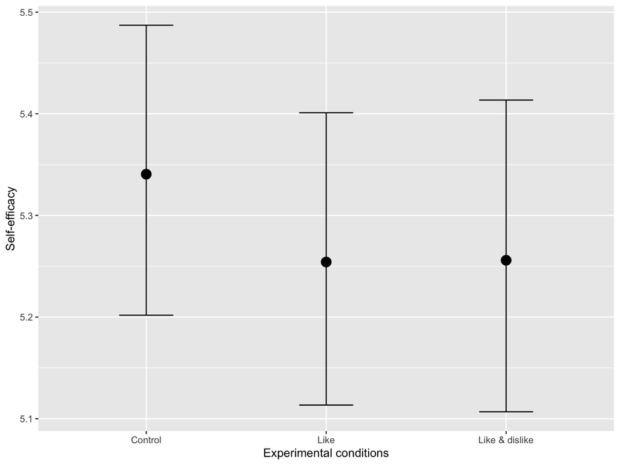

```r
run_hurdles(
  object = d,
  name = "selfeff_ctrl",
  outcome = "self_eff_fs",
  predictor = "version",
  y_lab = "Self-efficacy",
  x_lab = "Experimental conditions"
  )
```

I then compare the likes and control conditions to the likes plus dislikes condition.

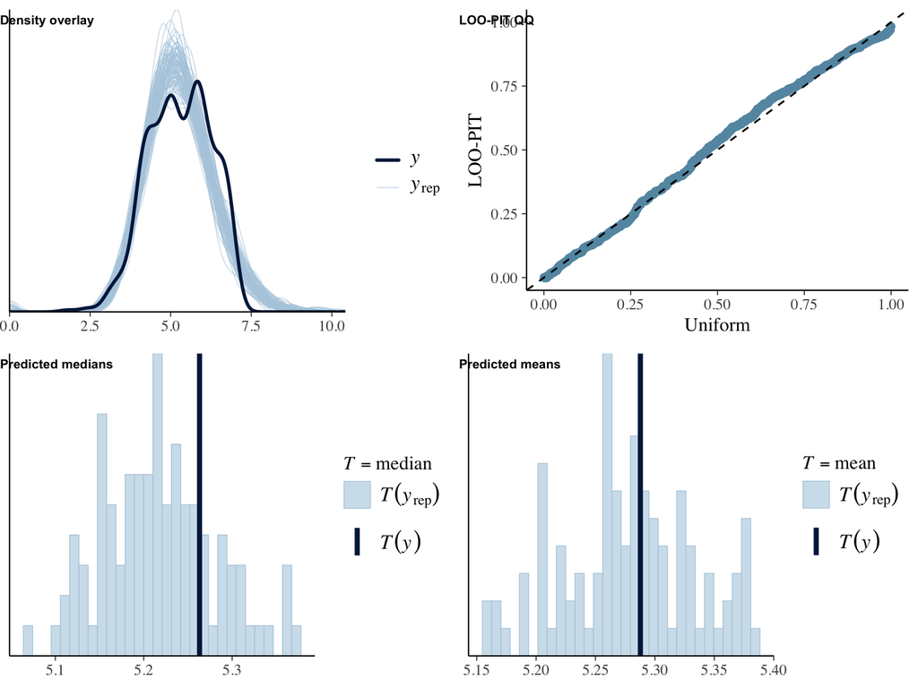

```
 Family: hurdle_gamma
  Links: mu = log; hu = logit
Formula: self_eff_fs ~ 1 + age + male + edu + version_lkdslk
         hu ~ 1 + age + male + edu + version_lkdslk
   Data: object (Number of observations: 558)
  Draws: 4 chains, each with iter = 1000; warmup = 500; thin = 1;
         total post-warmup draws = 2000

Regression Coefficients:
                         Estimate Est.Error l-95% CI u-95% CI Rhat Bulk_ESS Tail_ESS
Intercept                    1.61      0.03     1.54     1.68 1.00     2360     1615
hu_Intercept               -10.07      6.08   -23.64    -0.24 1.00     1065      963
age                         -0.00      0.00    -0.00     0.00 1.00     2351     1290
male                         0.01      0.02    -0.02     0.05 1.00     2424     1447
edu                          0.02      0.01     0.01     0.04 1.00     2788     1445
version_lkdslkLike          -0.00      0.02    -0.04     0.04 1.00     1826     1708
version_lkdslkControl        0.02      0.02    -0.02     0.06 1.00     1760     1536
hu_age                       0.00      0.08    -0.16     0.17 1.00     1935     1279
hu_male                     -0.13      3.07    -6.49     6.01 1.00     1374     1116
hu_edu                      -0.20      1.72    -3.86     3.08 1.00     1316      963
hu_version_lkdslkLike        0.12      4.74    -9.61    10.29 1.00      672      467
hu_version_lkdslkControl     0.32      4.58    -8.66    10.70 1.00      782      512

Further Distributional Parameters:
      Estimate Est.Error l-95% CI u-95% CI Rhat Bulk_ESS Tail_ESS
shape    27.95      1.66    24.84    31.21 1.00     1792     1363

Draws were sampled using sampling(NUTS). For each parameter, Bulk_ESS
and Tail_ESS are effective sample size measures, and Rhat is the potential
scale reduction factor on split chains (at convergence, Rhat = 1).
```

```
Results of marginal effects:
      Outcome           term                 contrast estimate conf.low conf.high
1 self_eff_fs            age                    dY/dX -0.00011 -0.00616   0.00577
2 self_eff_fs            edu                    dY/dX  0.13032  0.01832   0.24307
3 self_eff_fs           male                    1 - 0  0.07912 -0.08940   0.25650
4 self_eff_fs version_lkdslk Control - Like & dislike  0.09250 -0.12551   0.30151
5 self_eff_fs version_lkdslk    Like - Like & dislike  0.00252 -0.19700   0.20489
```

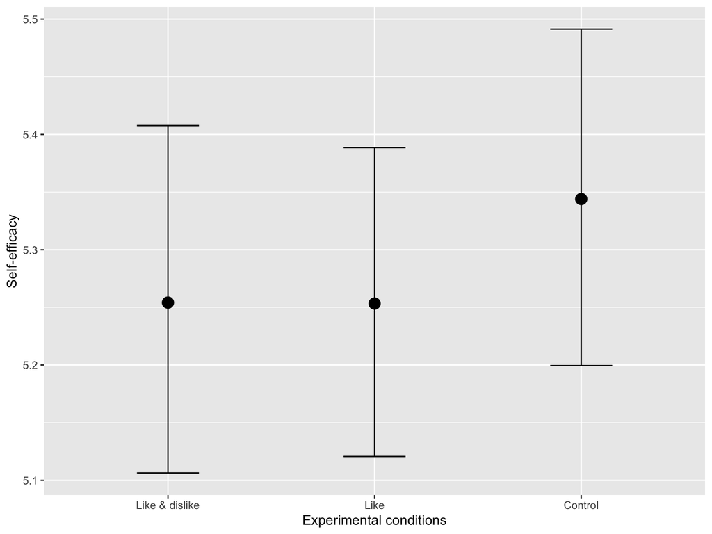

```r
run_hurdles(
  object = d,
  name = "selfeff_lkdslk",
  outcome = "self_eff_fs",
  predictor = "version_lkdslk",
  y_lab = "Self-efficacy",
  x_lab = "Experimental conditions"
  )
```

### Words

#### Privacy Concerns

```
Some PIT values larger than 1! Largest:  1
Rounding PIT > 1 to 1.
```

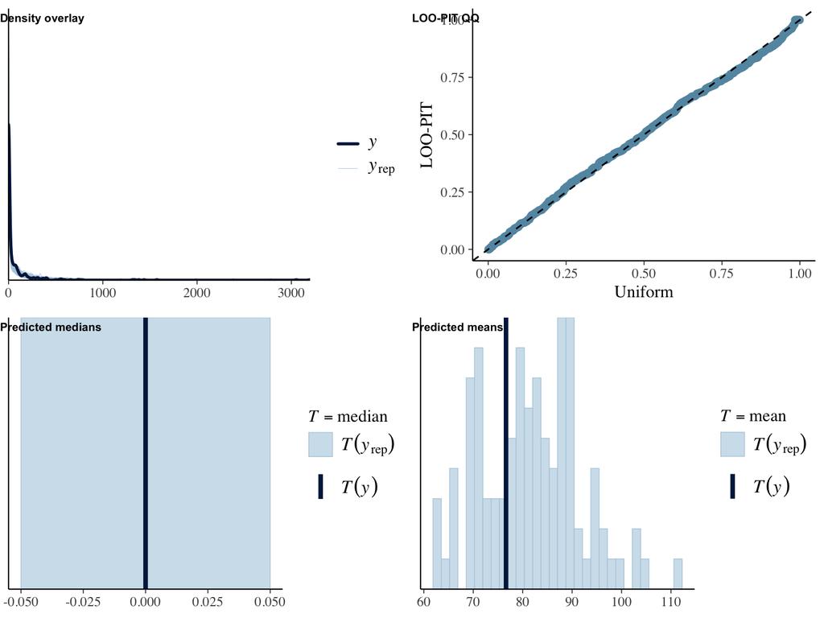

```
 Family: hurdle_gamma
  Links: mu = log; hu = logit
Formula: words ~ 1 + age + male + edu + pri_con_fs
         hu ~ 1 + age + male + edu + pri_con_fs
   Data: object (Number of observations: 558)
  Draws: 4 chains, each with iter = 1000; warmup = 500; thin = 1;
         total post-warmup draws = 2000

Regression Coefficients:
              Estimate Est.Error l-95% CI u-95% CI Rhat Bulk_ESS Tail_ESS
Intercept         5.66      0.40     4.87     6.46 1.00     3251     1598
hu_Intercept      0.54      0.40    -0.23     1.31 1.00     3598     1594
age              -0.00      0.01    -0.01     0.01 1.00     3389     1712
male             -0.08      0.17    -0.41     0.26 1.00     3557     1401
edu              -0.01      0.09    -0.19     0.17 1.00     3598     1467
pri_con_fs       -0.10      0.06    -0.21     0.02 1.00     3187     1540
hu_age           -0.01      0.01    -0.02     0.00 1.00     3204     1261
hu_male          -0.03      0.18    -0.38     0.32 1.00     3602     1425
hu_edu           -0.23      0.10    -0.44    -0.03 1.00     3874     1479
hu_pri_con_fs     0.19      0.06     0.08     0.30 1.00     3408     1842

Further Distributional Parameters:
      Estimate Est.Error l-95% CI u-95% CI Rhat Bulk_ESS Tail_ESS
shape     0.69      0.05     0.59     0.81 1.00     3231     1473

Draws were sampled using sampling(NUTS). For each parameter, Bulk_ESS
and Tail_ESS are effective sample size measures, and Rhat is the potential
scale reduction factor on split chains (at convergence, Rhat = 1).
```

```
Results of marginal effects:
  Outcome       term contrast estimate conf.low conf.high
1   words        age    dY/dX     0.19   -0.845      1.24
2   words        edu    dY/dX     8.70   -7.813     27.07
3   words       male    1 - 0    -4.85  -35.923     25.93
4   words pri_con_fs    dY/dX   -15.65  -27.575     -5.98
```

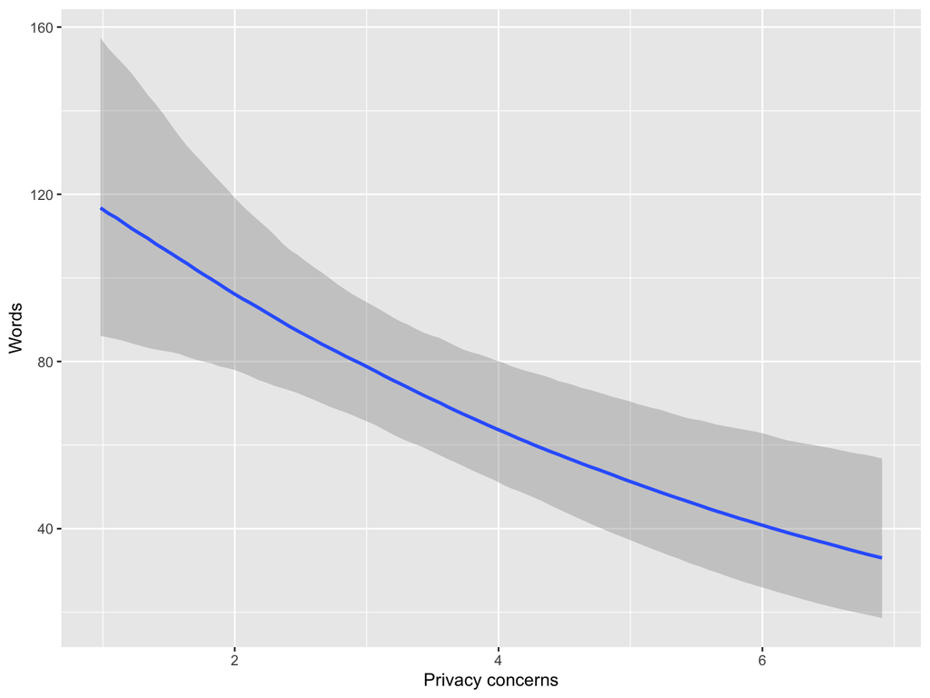

```r
run_hurdles(
  object = d,
  name = "wrds_pricon",
  outcome = "words",
  predictor = "pri_con_fs",
  y_lab = "Words",
  x_lab = "Privacy concerns"
  )
```

Let’s explore how number of communicated words differ for people very much concerned versus not concerned at all.

```r
# let's extract effects for 1
wrds_pricon_1 <-
  fig_wrds_pricon$data %>%
  filter(pri_con_fs == min(pri_con_fs)) %>%
  pull(estimate__) %>%
  round(0)

# let's extract effects for 7
wrds_pricon_7 <-
  fig_wrds_pricon$data %>%
  filter(pri_con_fs == max(pri_con_fs)) %>%
  pull(estimate__) %>%
  round(0)
```

People who were not concerned at all communicated on average 117 words, whereas people strongly concerned communicated on average 33 words.

#### Gratifications General

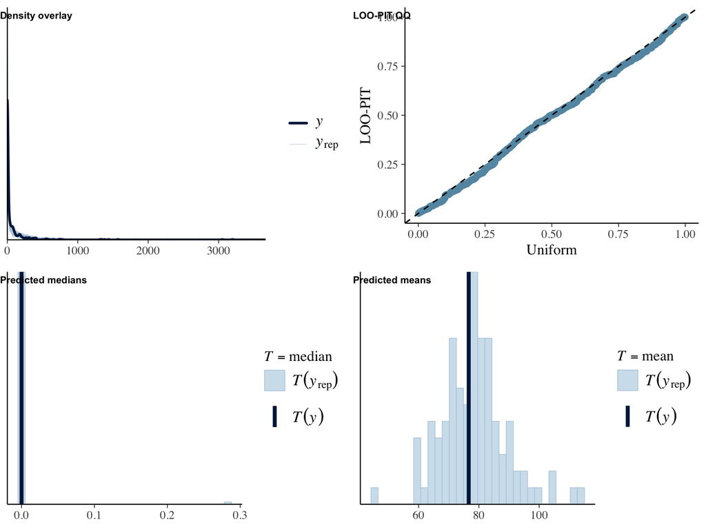

```
 Family: hurdle_gamma
  Links: mu = log; hu = logit
Formula: words ~ 1 + age + male + edu + grats_gen_fs
         hu ~ 1 + age + male + edu + grats_gen_fs
   Data: object (Number of observations: 558)
  Draws: 4 chains, each with iter = 1000; warmup = 500; thin = 1;
         total post-warmup draws = 2000

Regression Coefficients:
                Estimate Est.Error l-95% CI u-95% CI Rhat Bulk_ESS Tail_ESS
Intercept           4.28      0.45     3.40     5.18 1.00     3323     1894
hu_Intercept        2.25      0.52     1.26     3.33 1.00     3526     1703
age                -0.00      0.01    -0.01     0.01 1.00     3663     1918
male               -0.08      0.16    -0.40     0.21 1.00     3660     1595
edu                 0.03      0.09    -0.15     0.20 1.00     4451     1571
grats_gen_fs        0.22      0.07     0.08     0.35 1.00     3339     1659
hu_age             -0.01      0.01    -0.02     0.00 1.01     4228     1266
hu_male            -0.08      0.18    -0.44     0.27 1.00     4085     1675
hu_edu             -0.22      0.10    -0.42    -0.02 1.00     3237     1490
hu_grats_gen_fs    -0.22      0.08    -0.37    -0.08 1.00     3833     1402

Further Distributional Parameters:
      Estimate Est.Error l-95% CI u-95% CI Rhat Bulk_ESS Tail_ESS
shape     0.71      0.06     0.60     0.82 1.00     3500     1442

Draws were sampled using sampling(NUTS). For each parameter, Bulk_ESS
and Tail_ESS are effective sample size measures, and Rhat is the potential
scale reduction factor on split chains (at convergence, Rhat = 1).
```

```
Results of marginal effects:
  Outcome         term contrast estimate conf.low conf.high
1   words          age    dY/dX   0.0527   -0.966      1.03
2   words          edu    dY/dX  11.7367   -3.533     29.74
3   words grats_gen_fs    dY/dX  26.5574   13.870     43.50
4   words         male    1 - 0  -3.1669  -32.244     25.50
```

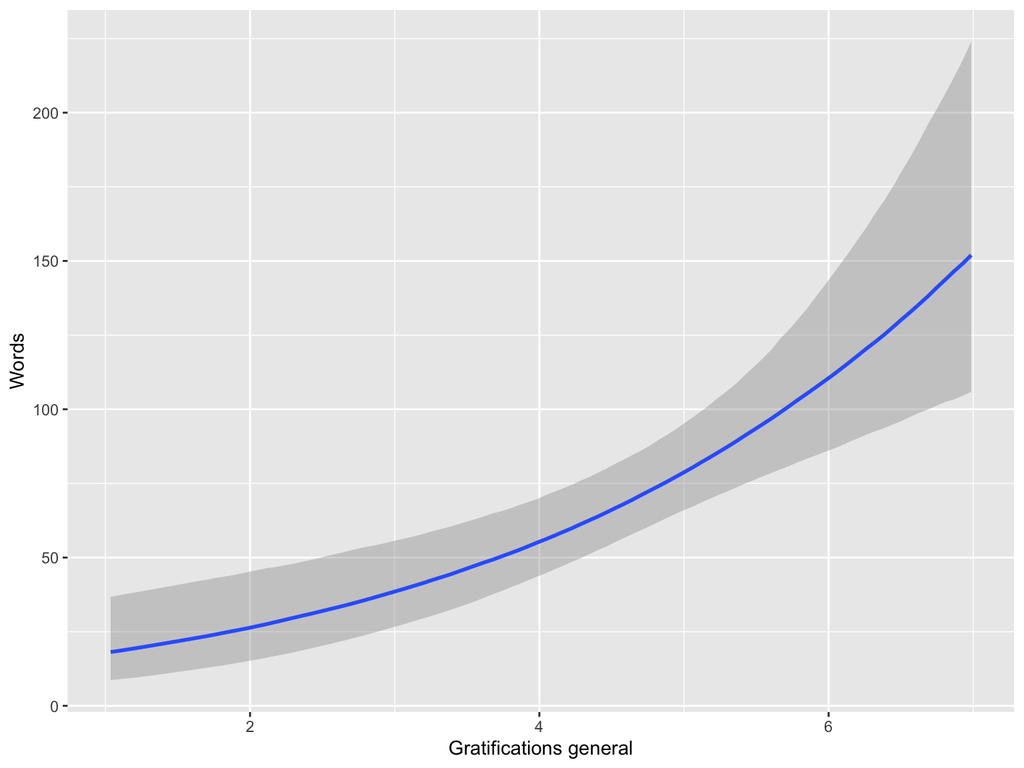

```r
run_hurdles(
  object = d,
  name = "wrds_grats",
  outcome = "words",
  predictor = "grats_gen_fs",
  y_lab = "Words",
  x_lab = "Gratifications general"
  )
```

#### Privacy Deliberation

```
Some PIT values larger than 1! Largest:  1
Rounding PIT > 1 to 1.
```

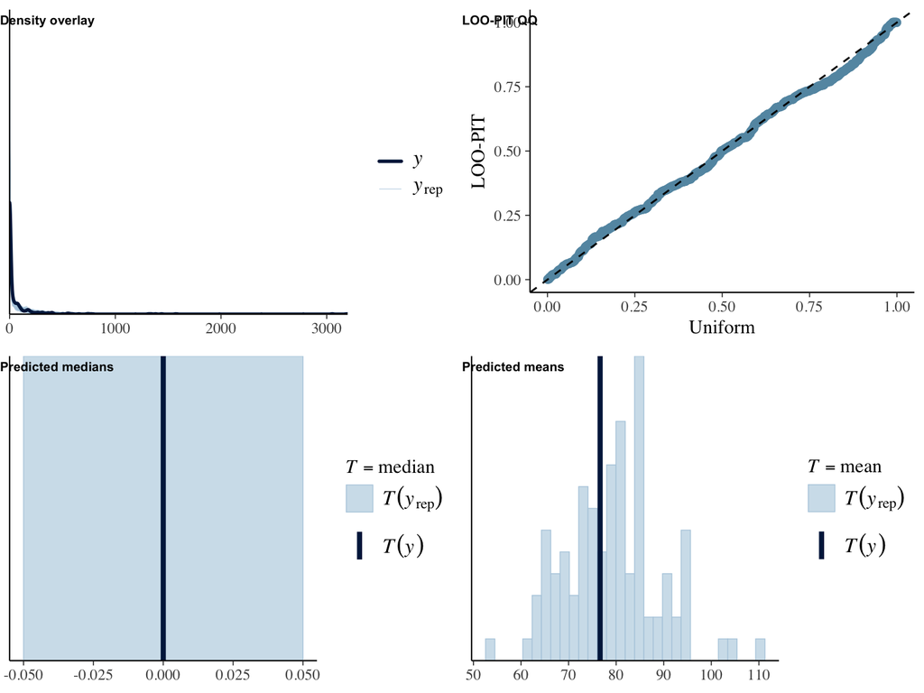

```
 Family: hurdle_gamma
  Links: mu = log; hu = logit
Formula: words ~ 1 + age + male + edu + pri_del_fs
         hu ~ 1 + age + male + edu + pri_del_fs
   Data: object (Number of observations: 558)
  Draws: 4 chains, each with iter = 1000; warmup = 500; thin = 1;
         total post-warmup draws = 2000

Regression Coefficients:
              Estimate Est.Error l-95% CI u-95% CI Rhat Bulk_ESS Tail_ESS
Intercept         6.50      0.48     5.58     7.47 1.00     3556     1504
hu_Intercept     -0.16      0.50    -1.12     0.81 1.00     5174     1605
age              -0.01      0.01    -0.02     0.01 1.00     3551     1523
male             -0.08      0.16    -0.40     0.24 1.00     3214     1625
edu              -0.02      0.09    -0.20     0.16 1.01     4918     1519
pri_del_fs       -0.26      0.07    -0.40    -0.12 1.00     3612     1533
hu_age           -0.01      0.01    -0.02     0.00 1.00     4087     1579
hu_male          -0.01      0.17    -0.35     0.33 1.00     3298     1508
hu_edu           -0.22      0.11    -0.43    -0.01 1.00     3618     1272
hu_pri_del_fs     0.30      0.08     0.14     0.46 1.00     4655     1421

Further Distributional Parameters:
      Estimate Est.Error l-95% CI u-95% CI Rhat Bulk_ESS Tail_ESS
shape     0.71      0.06     0.60     0.83 1.00     4381     1623

Draws were sampled using sampling(NUTS). For each parameter, Bulk_ESS
and Tail_ESS are effective sample size measures, and Rhat is the potential
scale reduction factor on split chains (at convergence, Rhat = 1).
```

```
Results of marginal effects:
  Outcome       term contrast estimate conf.low conf.high
1   words        age    dY/dX   -0.167    -1.21     0.792
2   words        edu    dY/dX    7.622    -9.04    24.031
3   words       male    1 - 0   -6.134   -35.83    23.755
4   words pri_del_fs    dY/dX  -33.166   -51.10   -19.815
```

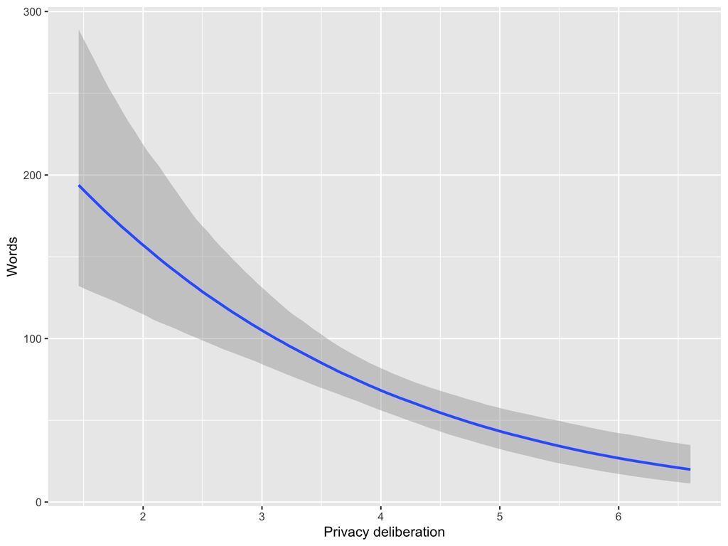

```r
run_hurdles(
  object = d,
  name = "wrds_pridel",
  outcome = "words",
  predictor = "pri_del_fs",
  y_lab = "Words",
  x_lab = "Privacy deliberation"
  )
```

#### Trust General

```
Some PIT values larger than 1! Largest:  1
Rounding PIT > 1 to 1.
```

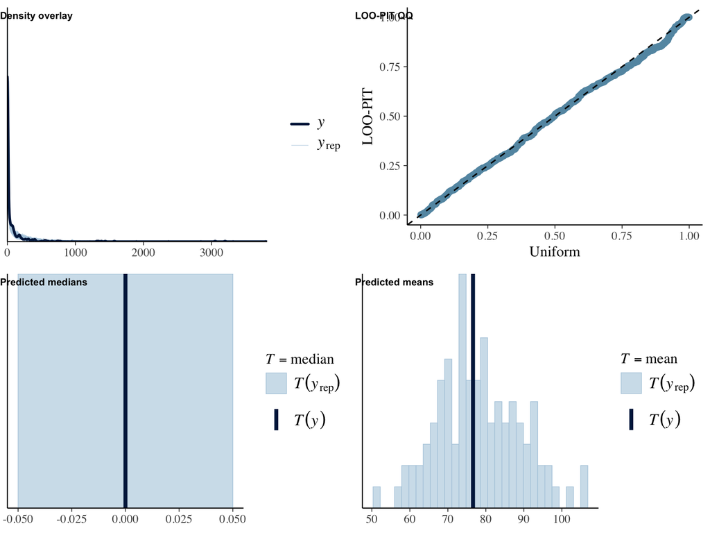

```
 Family: hurdle_gamma
  Links: mu = log; hu = logit
Formula: words ~ 1 + age + male + edu + trust_gen_fs
         hu ~ 1 + age + male + edu + trust_gen_fs
   Data: object (Number of observations: 558)
  Draws: 4 chains, each with iter = 1000; warmup = 500; thin = 1;
         total post-warmup draws = 2000

Regression Coefficients:
                Estimate Est.Error l-95% CI u-95% CI Rhat Bulk_ESS Tail_ESS
Intercept           4.25      0.59     3.13     5.41 1.00     3233     1706
hu_Intercept        3.09      0.63     1.88     4.35 1.00     4178     1399
age                -0.00      0.01    -0.01     0.01 1.00     4576     1757
male               -0.08      0.17    -0.40     0.26 1.00     3528     1353
edu                -0.01      0.10    -0.19     0.17 1.00     3699     1284
trust_gen_fs        0.21      0.10     0.01     0.40 1.00     3575     1525
hu_age             -0.01      0.01    -0.02     0.00 1.00     3621     1380
hu_male            -0.07      0.17    -0.40     0.26 1.00     4090     1447
hu_edu             -0.21      0.11    -0.41    -0.01 1.00     3665     1484
hu_trust_gen_fs    -0.36      0.09    -0.53    -0.17 1.00     4142     1525

Further Distributional Parameters:
      Estimate Est.Error l-95% CI u-95% CI Rhat Bulk_ESS Tail_ESS
shape     0.70      0.05     0.59     0.81 1.00     5120     1577

Draws were sampled using sampling(NUTS). For each parameter, Bulk_ESS
and Tail_ESS are effective sample size measures, and Rhat is the potential
scale reduction factor on split chains (at convergence, Rhat = 1).
```

```
Results of marginal effects:
  Outcome         term contrast estimate conf.low conf.high
1   words          age    dY/dX    0.274    -0.70      1.28
2   words          edu    dY/dX    8.352    -9.39     25.82
3   words         male    1 - 0   -2.623   -34.42     27.20
4   words trust_gen_fs    dY/dX   31.140    14.40     51.85
```

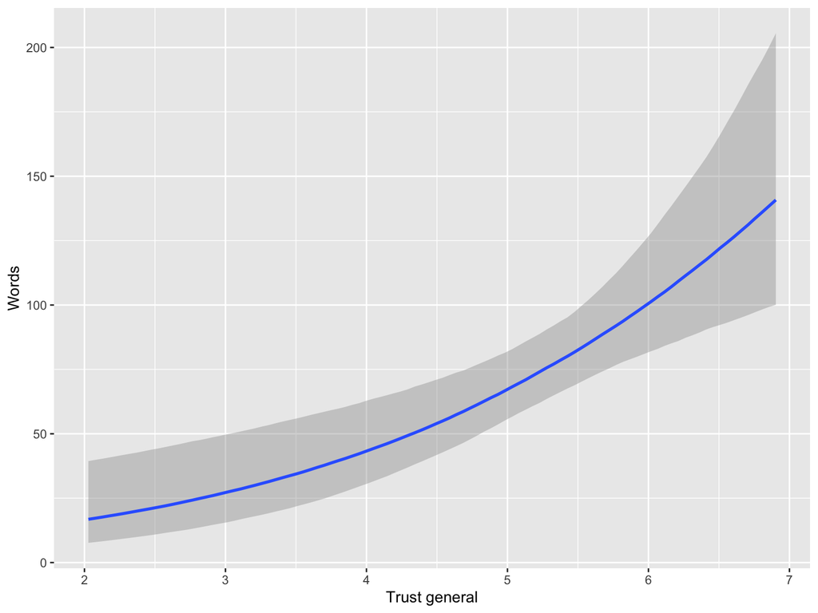

```r
run_hurdles(
  object = d,
  name = "wrds_trust",
  outcome = "words",
  predictor = "trust_gen_fs",
  y_lab = "Words",
  x_lab = "Trust general"
  )
```

#### Self-Efficacy

```
Some PIT values larger than 1! Largest:  1
Rounding PIT > 1 to 1.
```

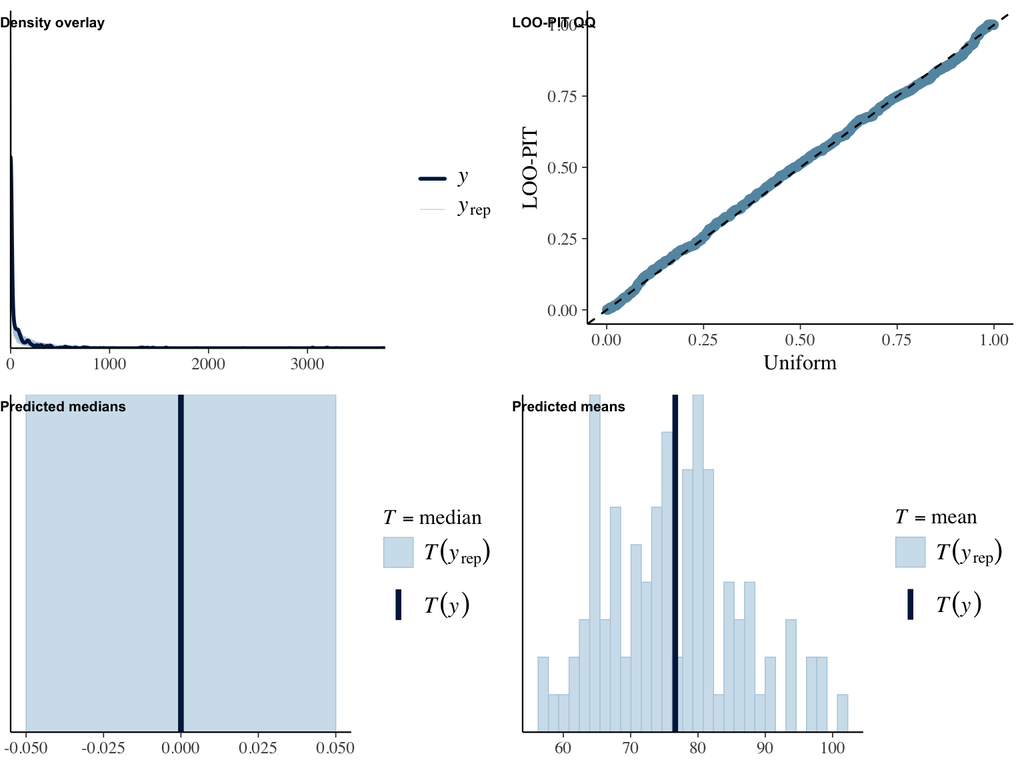

```
 Family: hurdle_gamma
  Links: mu = log; hu = logit
Formula: words ~ 1 + age + male + edu + self_eff_fs
         hu ~ 1 + age + male + edu + self_eff_fs
   Data: object (Number of observations: 558)
  Draws: 4 chains, each with iter = 1000; warmup = 500; thin = 1;
         total post-warmup draws = 2000

Regression Coefficients:
               Estimate Est.Error l-95% CI u-95% CI Rhat Bulk_ESS Tail_ESS
Intercept          2.18      0.45     1.30     3.10 1.00     3880     1728
hu_Intercept       5.77      0.71     4.39     7.19 1.01     3800     1615
age               -0.00      0.01    -0.01     0.01 1.00     3934     1417
male              -0.16      0.15    -0.44     0.15 1.00     3601     1466
edu               -0.06      0.08    -0.23     0.10 1.00     4138     1750
self_eff_fs        0.58      0.07     0.44     0.72 1.00     3207     1715
hu_age            -0.01      0.01    -0.02     0.00 1.00     3344     1446
hu_male           -0.01      0.20    -0.40     0.37 1.00     4029     1488
hu_edu            -0.12      0.11    -0.35     0.11 1.00     3976     1560
hu_self_eff_fs    -0.88      0.11    -1.09    -0.68 1.00     3917     1679

Further Distributional Parameters:
      Estimate Est.Error l-95% CI u-95% CI Rhat Bulk_ESS Tail_ESS
shape     0.80      0.06     0.68     0.94 1.00     4667     1493

Draws were sampled using sampling(NUTS). For each parameter, Bulk_ESS
and Tail_ESS are effective sample size measures, and Rhat is the potential
scale reduction factor on split chains (at convergence, Rhat = 1).
```

```
Results of marginal effects:
  Outcome        term contrast estimate conf.low conf.high
1   words         age    dY/dX   0.0173   -0.913     0.926
2   words         edu    dY/dX  -0.5496  -16.887    13.609
3   words        male    1 - 0 -11.8263  -36.600    13.181
4   words self_eff_fs    dY/dX  72.2424   55.933    94.528
```

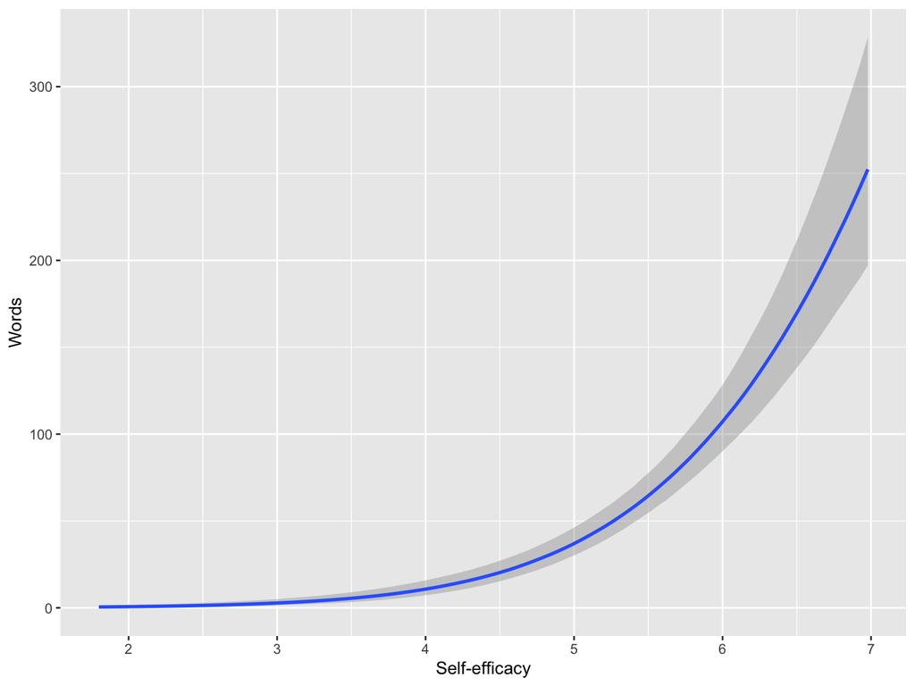

```r
run_hurdles(
  object = d,
  name = "wrds_selfeff",
  outcome = "words",
  predictor = "self_eff_fs",
  y_lab = "Words",
  x_lab = "Self-efficacy"
  )
```

The effects is markedly exponential. Let’s inspect the changes across values in self-efficacy.

```r
effects_wrds_selfeff <-
  slopes(
    fit_wrds_selfeff,
    newdata = datagrid(
      self_eff_fs = c(1, 6, 7)
      ),
   grid_type = "counterfactual"
    ) %>%
  filter(
    term == "self_eff_fs"
    ) %T>%
  print()
```

```
 self_eff_fs Estimate    2.5 %  97.5 %
           1    0.253   0.0935   0.632
           6  110.989  80.8473 150.902
           7  218.439 142.3287 333.014

Term: self_eff_fs
Type: response
Comparison: dY/dX
```

```r
# let's extract effects for 1
effects_wrds_selfeff_12 <-
  effects_wrds_selfeff %>%
  filter(
    self_eff_fs == 1 &
      term == "self_eff_fs") %>%
  select(estimate)

# let's extract effects for 7
effects_wrds_selfeff_67 <-
  effects_wrds_selfeff %>%
  filter(
    self_eff_fs == 6 &
      term == "self_eff_fs") %>%
  select(estimate)
```

Whereas a change in self-efficacy from 1 to 2 led to an increase of 0 words, a change from 6 to 7 led to an increase of 111 words.

Let’s explore how number of communicated words differ for people very much self-efficacious versus not self-efficacious at all.

```r
# let's extract effects for 1
wrds_selfeff_1 <-
  fig_wrds_selfeff$data %>%
  filter(self_eff_fs == min(self_eff_fs)) %>%
  pull(estimate__) %>%
  round(0)

# let's extract effects for 7
wrds_selfeff_7 <-
  fig_wrds_selfeff$data %>%
  filter(self_eff_fs == max(self_eff_fs)) %>%
  pull(estimate__) %>%
  round(0)
```

People who reported no self-efficacy at all communicated on average 1 words, whereas people with very high self-efficacy communicated on average 252 words.

## Visualization

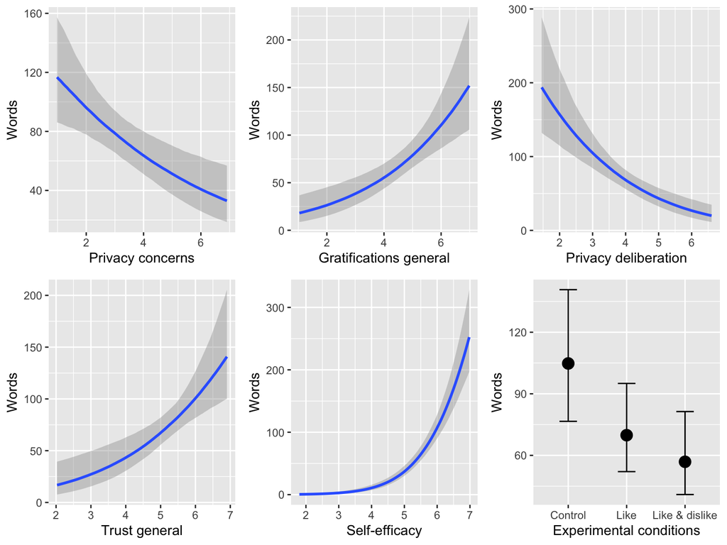

```r
fig_results <-
  plot_grid(
    fig_wrds_pricon,
    fig_wrds_grats,
    fig_wrds_pridel,
    fig_wrds_trust,
    fig_wrds_selfeff,
    fig_wrds_ctrl
    ) %T>%
  print()
```

```r
# Save visualizations
ggsave("figures/results/effects.pdf")
ggsave("figures/results/effects.png")
```

## Table

Make table of slopes

```r
tab_slopes <-
  rbind(
    slopes_wrds_pricon,
    slopes_wrds_grats,
    slopes_wrds_pridel,
    slopes_wrds_trust,
    slopes_wrds_selfeff,
    slopes_wrds_ctrl,
    slopes_wrds_lkdslk,
    slopes_pricon_ctrl,
    slopes_pricon_lkdslk,
    slopes_grats_ctrl,
    slopes_grats_lkdslk,
    slopes_pridel_ctrl,
    slopes_pridel_lkdslk,
    slopes_trust_ctrl,
    slopes_trust_lkdslk,
    slopes_selfeff_ctrl,
    slopes_selfeff_lkdslk
    ) %>%
  as.data.frame() %>%
  mutate(
    term = ifelse(
      .$contrast == "Like - Control",
      "Like - Control",
      ifelse(
        .$contrast == "Like & dislike - Control",
        "Like & dislike - Control",
        ifelse(
          .$contrast == "Like - Like & dislike",
          "Like - Like & dislike",
          .$term
          )
        )
      ),
    Predictor = recode(
      term,
      "Like - Control" = "Like vs. control",
      "Like & dislike - Control" = "Like & dislike vs. control",
      "Like - Like & dislike" = "Like vs. like & dislike",
      "pri_con_fs" = "Privacy concerns",
      "pri_del_fs" = "Privacy deliberation",
      "grats_gen_fs" = "Expected gratifications",
      "trust_gen_fs" = "Trust",
      "self_eff_fs" = "Self-efficacy"
    ),
    Outcome = recode(
      Outcome,
      "pri_con_fs" = "Privacy concerns",
      "pri_del_fs" = "Privacy deliberation",
      "grats_gen_fs" = "Expected gratifications",
      "trust_gen_fs" = "Trust",
      "self_eff_fs" = "Self-efficacy"
    )
  ) %>%
  filter(
    Predictor %in% c(
      "Like vs. control",
      "Like & dislike vs. control",
      "Like vs. like & dislike",
      "Privacy concerns",
      "Privacy deliberation",
      "Expected gratifications",
      "Trust",
      "Self-efficacy")
  ) %>%
  mutate(
    Predictor = factor(Predictor, levels = c(
      "Self-efficacy",
      "Trust",
      "Privacy deliberation",
      "Expected gratifications",
      "Privacy concerns",
      "Like vs. like & dislike",
      "Like & dislike vs. control",
      "Like vs. control"
      )
    ),
    Estimate =
      ifelse(
        Outcome == "words",
        round(estimate),
        estimate
      ),
    LL =
      ifelse(
        Outcome == "words",
        round(conf.low),
        conf.low
      ),
    UL =
      ifelse(
        Outcome == "words",
        round(conf.high),
        conf.high
      ),
  ) %>%
  select(
    Outcome,
    Predictor,
    Estimate,
    LL,
    UL
    )

tab_slopes %>%
  kable() %>%
  kable_styling("striped") %>%
  scroll_box(width = "100%")
```

| Outcome | Predictor | Estimate | LL | UL |
| --- | --- | --- | --- | --- |
| words | Privacy concerns | -16.000 | -28.000 | -6.000 |
| words | Expected gratifications | 27.000 | 14.000 | 43.000 |
| words | Privacy deliberation | -33.000 | -51.000 | -20.000 |
| words | Trust | 31.000 | 14.000 | 52.000 |
| words | Self-efficacy | 72.000 | 56.000 | 95.000 |
| words | Like & dislike vs. control | -47.000 | -90.000 | -10.000 |
| words | Like vs. control | -35.000 | -75.000 | 2.000 |
| words | Like vs. like & dislike | 13.000 | -18.000 | 44.000 |
| Privacy concerns | Like & dislike vs. control | 0.176 | -0.163 | 0.520 |
| Privacy concerns | Like vs. control | 0.030 | -0.289 | 0.361 |
| Privacy concerns | Like vs. like & dislike | -0.135 | -0.491 | 0.196 |
| Expected gratifications | Like & dislike vs. control | -0.213 | -0.489 | 0.054 |
| Expected gratifications | Like vs. control | -0.173 | -0.431 | 0.087 |
| Expected gratifications | Like vs. like & dislike | 0.042 | -0.212 | 0.299 |
| Privacy deliberation | Like & dislike vs. control | -0.044 | -0.304 | 0.203 |
| Privacy deliberation | Like vs. control | -0.010 | -0.256 | 0.238 |
| Privacy deliberation | Like vs. like & dislike | 0.042 | -0.194 | 0.285 |
| Trust | Like & dislike vs. control | -0.125 | -0.331 | 0.082 |
| Trust | Like vs. control | -0.145 | -0.348 | 0.062 |
| Trust | Like vs. like & dislike | -0.020 | -0.225 | 0.178 |
| Self-efficacy | Like & dislike vs. control | -0.086 | -0.305 | 0.134 |
| Self-efficacy | Like vs. control | -0.086 | -0.283 | 0.114 |
| Self-efficacy | Like vs. like & dislike | 0.003 | -0.197 | 0.205 |

Back to top

## References

Rohrer, Julia M. 2018. “Thinking Clearly about Correlations and Causation: Graphical Causal Models for Observational Data.” *Advances in Methods and Practices in Psychological Science* 24 (2): 251524591774562. https://doi.org/10.1177/2515245917745629.